# How do Certain Factors Affect the Ratings of Boardgames?

Too Legit To Overfit

## Summary

We explore how different variables (category, average and minimum playing time, year published, and number of ratings) affect the average rating of a board game on BoardGameGeek.com. In particular, we attempt to predict the average rating of a board game from these variables.

The dataset we use contains 22 properties, such as the variables listed above, on 10174 board games. We sourced the data from [TidyTuesday](https://github.com/rfordatascience/tidytuesday/tree/master/data/2019/2019-03-12), though they originally come from [Board Game Geek](http://boardgamegeek.com/). For more information about the data, see [our data page](https://github.com/ids-s1-20/project-too_legit_to_overfit/blob/main/data/README.md).

For our analyses, we use R to explore and manipulate the data, in particular using `tidyverse` for manipulation, and `tidymodels` for modelling. We use v-fold cross-validation to obtain Root Mean Square Error (RMSE) and (adjusted) $R ^ 2$ values with which we can accurately compare models.

Looking first at game categories, we opted to use only the top 6 most frequent categories, as there are 83 categories overall, and it would be impractical to compare all of them at once. Furthermore, the top 6 categories — Card Game, Wargame, Fantasy, Fighting, Economic, and Science Fiction — cover 67% of our data, which still leaves 6773 games.

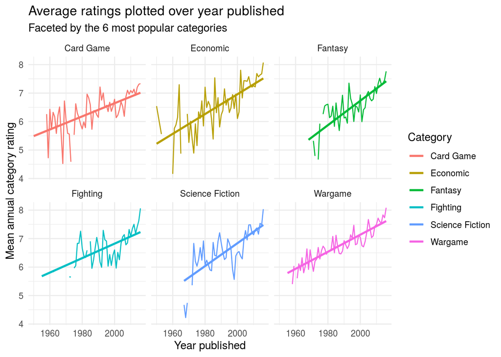

Despite for each category there being a lot of fluctuation in the average ratings of games published over the years, the linear models fitted to each plot all have a positive slope. This implies that there is a positive correlation present in these categories between their average rating and year published. The residuals for each category in this model are randomly distributed around zero, supporting the appropriateness of fitting a linear model.

Looking at the results for this model, card games are rated on average the lowest out of these six categories, taking an average rating of 6.26 out of 10. However, even wargames, which have the greatest average difference from card games in average ratings, has only an average rating of 6.77. This suggests that category has minimal effect on the rating of the game.

We look now at the year in which the game was published. Apart from a few particularly low spikes in the 1950s and ’60s where there were a few outliers due to very few games being released in that year, we can see that on average, there is an upwards trend in the ratings of games, which suggests that newer games tend to be better rated by the Board Game Geek community. However, as we can see from the low $R^2$ value of 0.095, the model does not well explain the variance in average rating.

Following on with investigating the effect of playing time on average rating, a scatter plot of average rating against average playing time (see our [slides](https://github.com/ids-s1-20/project-too_legit_to_overfit/blob/main/presentation/presentation.html) or [video](https://media.ed.ac.uk/media/IDS+Project+Presentation+-+too+legit+to+overfit/1_040ko2d8)) reveals a slight positive correlation between the two. To investigate this further, we construct two linear regression models: one with average playing time, and one with both average and minimum playing time. The drastic difference in slopes of average playing time between the former model ($0.314$), and the latter ($0.771$, with minimum playing time having a slope of $-0.485$) is a sign of collinearity between playing time and minimum playing time, which is obviously bad for a linear regression model. From the slopes of the double variable model, we can see that given the same average playing time, games with shorter minimum playing times tend to have higher ratings on average.

In both models, the RMSEs are relatively high (single variable model has training data $RMSE = 0.79$, test data $RMSE = 0.786$; double variable model has training data $RMSE = 0.781$, test data $RMSE = 0.772$.) in respect to the range of average ratings. Most of the data is distributed between an average rating of 2.5 and 8, which means the standard error is around 15%, which is quite bad.

The adjusted $R^2$ values for both models are fairly low (single variable model: $R^2=0.121$, $R^2=0.153$). However, relative to models with the other variables, the adjusted $R^2$ is high, meaning that there may be more of a relationship between average rating and playing time compared to the other variables explored.

Now we look at number of ratings. In this dataset, games with few ratings have a large variation in average rating, but this variation quickly reduces as number of ratings increases. This variation in average rating for games with fewer ratings could be because smaller sample sizes mean our sample average ratings are less reliable predictions of the true average ratings one would get were everyone to rate the games.

Interestingly, aside from slight negative skew (because ratings fall only between 0 and 10), the distribution of average ratings is very close to a normal distribution of
$$Y\sim N(6.371,0.85^2).$$
It would be interesting to model how the distribution of average rating varied across number of ratings, though this was not something we were able to do.

Again, it is worth noting that the linear regression model with number of ratings isn’t great. This is partly due to non-constant variance of average rating across number of ratings, meaning we can believe the predictions for low numbers of ratings a lot more than for higher numbers. It is also because one should not expect to be able to accurately predict the average rating of a game from only the number of ratings it has received. The success of a game depends on many factors, including many we do not look it such as game mechanics, game design, and of course the people who play.

Before wrapping up, we would like to discuss the following plot.

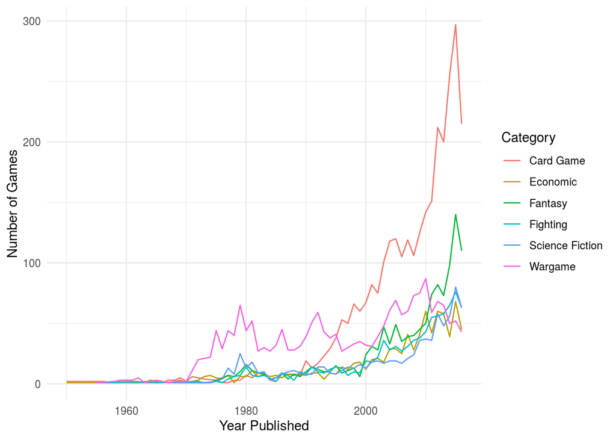

Though this does not relate to average rating, we think it is interesting enough to share. We can see that in 1970, wargames took off quite drastically probably due to the rise of companies like Avalon Hill, and stayed dominant for a few decades until about 1990, when card games shot up, which may or may not be due to the rise of the internet, and people being able to design, print, and publish their own card games much more cheaply and easily.

To conclude, we look model all the variables in one linear regression model. Other than being a wargame (which now, all else held constant, results in an average rating of 0.921 higher than card games — yes, this is significantly higher than in the single variable model with categories), each variable we looked at contributes to an increase in the average rating by less than a half (per unit increase in that variable). However, the RMSE of the model is large (0.695647 for testing data) and the $R^2$ value low (0.3264432 for testing data), so it is not a particularly accurate model. None of these variables are accurate predictors of the average rating of a board game. As mentioned before, this is to be expected because there is much more to a game than merely its genre, playing time, etc.

Moral of the story:

## References

### Data

Board Game Geek 2019, *Board Games Database*, electronic dataset, Tidy Tuesdays, viewed 23 October 2020, https://github.com/rfordatascience/tidytuesday/tree/master/data/2019/2019-03-12.

### Code

Jeto N 2015, *Fitting Distributions*, University of Lisbon, viewed 22 Nov 2020, http://www.di.fc.ul.pt/~jpn/r/distributions/fitting.html

Sauer S 2017, *Simple way of plotting normal/logistic/etc. curve*, sebastiansauer.github.io, viewed 22 Nov 2020, https://sebastiansauer.github.io/plotting_s-curve/